# Impact off Weather Events in US on Health & Economy

Weather events have impact on the peoples health and economy. The idea of this project it to identify top events that have the most impact on health & Economy. Data published by National Climatic Data Center will be used for analysis.

## Data Processing

The data for Storm Data Events is sourced from National Climatic Data Center. [Here](https://d396qusza40orc.cloudfront.net/repdata%2Fdata%2FStormData.csv.bz2) is the link for the data file.

There is also some documentation of the database available. Here you will find how some of the variables are constructed/defined.  
* National Weather Service [Storm Data Documentation](https://d396qusza40orc.cloudfront.net/repdata%2Fpeer2_doc%2Fpd01016005curr.pdf)  
* National Climatic Data Center Storm Events [FAQ](https://d396qusza40orc.cloudfront.net/repdata%2Fpeer2_doc%2FNCDC%20Storm%20Events-FAQ%20Page.pdf)

```r
stormdata<-read.csv('repdata_data_StormData.csv.bz2')
stormdata$EVTYPE=as.character(stormdata$EVTYPE)
```

The EVTYPE information in the ‘repdata_data_StormData.csv.bz2’ needs some tranformation before data can be analyzed. It has issues like

1. Spelling  
   example:
   - BEACH EROSIN
   - AVALANCE
2. Event mapped with multiple categories  
   example:
   - BLIZZARD/HEAVY SNOW
3. Abbrevations & special characters  
   example:
   - BLOWING SNOW & EXTREME WIND CH
   - BLOWING SNOW- EXTREME WIND CHI
   - BLOWING SNOW/EXTREME WIND CHIL

There are about 977 distinct in events ‘repdata_data_StormData.csv.bz2’.

```r
#no. of unique EVTYPE
length(unique(trimws(stormdata$EVTYPE)))
```

```
## [1] 977
```

These 977 events have been mapped to one of the following storm data events

```
1. Astronomical Low Tide                  17. Funnel Cloud                          33. Marine Thunderstorm Wind
2. Avalanche                              18. Freezing Fog                          34. Rip Current
3. Blizzard                               19. Hail                                  35. Seiche
4. Coastal Flood                          20. Heat                                  36. Sleet
5. Cold/Wind Chill                        21. Heavy Rain                            37. Storm Surge/Tid
6. Debris Flow                            22. Heavy Snow                            38. Strong Wind
7. Dense Fog                              23. High Surf                             39. Thunderstorm Wind
8. Dense Smoke                            24. High Wind                             40. Tornado
9. Drought                                25. Hurricane (Typhoon)                   41. Tropical Depression
10. Dust Devil                            26. Ice Storm                             42. Tropical Storm
11. Dust Storm                            27. Lake-Effect Snow                      43. Tsunami
12. Excessive Heat                        28. Lakeshore Flood                       44. Volcanic Ash
13. Extreme Cold/Wind Chill               29. Lightning                             45. Waterspout
14. Flash Flood                           30. Marine Hail                           46. Wildfire
15. Flood                                 31. Marine High Wind                      47. Winter Storm
16. Frost/Freeze                          32. Marine Strong Wind                    48. Winter Weather
```

Reporting will be done on the above events. The event list has be sourced from [Storm Data Event List](https://d396qusza40orc.cloudfront.net/repdata%2Fpeer2_doc%2Fpd01016005curr.pdf) section 2.1.1 on page 6.

```r
library(knitr)
library(dplyr)
events<-read.csv('events.csv',header=TRUE,colClasses = "character")

#if event_type has comma, replace it with space character
stormdata$event_type<-lapply(stormdata$EVTYPE, function (x) {events[events$EVTYPE==gsub(","," ",trimws(c(x))),]$EVENT})
stormdata$event_type=as.factor(as.character(stormdata$event_type))
```

```r
library(dplyr)
stormdata$BGN_DATE<-as.Date(as.character(stormdata$BGN_DATE),format="%m/%d/%Y %H:%M:%S")
gdata<-group_by(stormdata,EVTYPE)
rdata<-summarize(gdata,bdate=min(BGN_DATE))
length(rdata[rdata$bdate < as.Date("1/1/1996","%m/%d/%Y"),]$EVTYPE)
```

```
## [1] 598
```

For analysis purpose data from 01-Jan-1996 is used.

```r
dataset<-stormdata[stormdata$BGN_DATE >=  as.Date("1/1/1996","%m/%d/%Y"),]
```

For analysics economic impact value of the property/crop damaged will be calculated using the fields PROPDMG/CROPDMP and PROPDMGEXP/CROPDMGEXP. PROPDMGEXP column has exponential value to the power of 10. Two new columns “PROPAMOUNT” & “CROPAMOUNT” are introduced to captured the value of the damage.

```r
expfunc<-function (x) {

        if (x=='') return(0)
        else if (x=='+') return(0)
        else if (x=='-') return(0)
        else if (x=='?') return(0)
        else if (x %in% c('h','H')) return(2)
        else if (x %in% c('k','K')) return(3)
        else if (x %in% c('m','M')) return(6)
        else if (x %in% c('b','B')) return(9)
        else return(as.numeric(as.character(x)))
      }
dataset$EXPONUM<-sapply(dataset$PROPDMGEXP,FUN=expfunc)
dataset$PROPAMOUNT<- dataset$PROPDMG * (10 ** dataset$EXPONUM)

dataset$EXPONUM<-sapply(dataset$CROPDMGEXP,FUN=expfunc)
dataset$CROPAMOUNT<- dataset$CROPDMG * (10 ** dataset$EXPONUM)
```

## Analyze and identify most Harmful Events

Aggregate fatalities and injuries based on events

```r
gdata<-group_by(dataset,event_type)
harmfuldata<-summarize(gdata,fatalities=sum(FATALITIES),injuries=sum(INJURIES))

fatalities<-head(harmfuldata[order(harmfuldata$fatalities,decreasing =TRUE),], 5)
injuries<-head(harmfuldata[order(harmfuldata$injuries,decreasing=TRUE),], 5)
```

Top 5 events that are most deaths are

```r
fatalities[,c('event_type','fatalities')]
```

```
## Source: local data frame [5 x 2]
##
##    event_type fatalities
##        (fctr)      (dbl)
## 1        Heat       2034
## 2     Tornado       1513
## 3 Flash Flood        889
## 4   Lightning        651
## 5 Rip Current        542
```

Top 5 events that are most inuries are

```r
injuries[,c('event_type','injuries')]
```

```
## Source: local data frame [5 x 2]
##
##          event_type injuries
##              (fctr)    (dbl)
## 1           Tornado    20669
## 2              Heat     7700
## 3             Flood     6758
## 4 Thunderstorm Wind     5170
## 5         Lightning     4141
```

## Analyze impact of stormdata events on economy

Aggreggate the damages to the properties and crops

```r
gdata<-group_by(dataset,event_type)
ecodata<-summarize(gdata,TOTALPROPDMG=sum(PROPAMOUNT),TOTALCROPDMG=sum(CROPAMOUNT))

properties<-head(ecodata[order(ecodata$TOTALPROPDMG,decreasing =TRUE),], 5)
crops<-head(ecodata[order(ecodata$TOTALCROPDMG,decreasing=TRUE),], 5)

ecodata$TOTALDMG<-(ecodata$TOTALPROPDMG+ecodata$TOTALCROPDMG)/1000000

totaldmg<-head(ecodata[order(ecodata$TOTALDMG,decreasing=TRUE),], 5)
```

Top 5 events that caused most property damages

```r
properties[,c('event_type','TOTALPROPDMG')]
```

```
## Source: local data frame [5 x 2]
##
##            event_type TOTALPROPDMG
##                (fctr)        (dbl)
## 1               Flood 143944833550
## 2 Hurricane (Typhoon)  81718889010
## 3    Storm Surge/Tide  47834774000
## 4             Tornado  24622675910
## 5         Flash Flood  15349708910
```

Top 5 events that cause most crop damages

```r
crops[,c('event_type','TOTALCROPDMG')]
```

```
## Source: local data frame [5 x 2]
##
##            event_type TOTALCROPDMG
##                (fctr)        (dbl)
## 1             Drought  13367566000
## 2 Hurricane (Typhoon)   5350107800
## 3               Flood   4974778400
## 4        Frost/Freeze   2677784000
## 5                Hail   2496822450
```

## Results Summary

The following two bar plots shows the top 5 events having most impact on the population health.

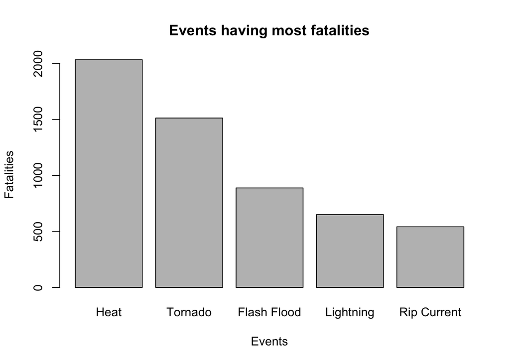

```r
barplot(as.numeric(fatalities$fatalities),names.arg=fatalities$event_type,xlab="Events", ylab="Fatalities", horiz=FALSE,main="Events having most fatalities")
```

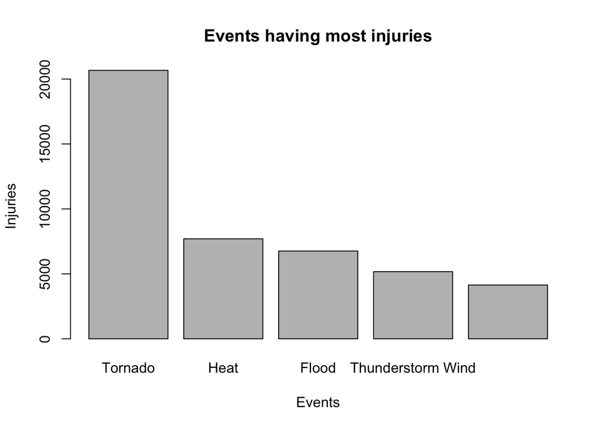

```r
barplot(injuries$injuries,names.arg=injuries$event_type,xlab="Events",ylab="Injuries",horiz=FALSE,main="Events having most injuries")
```

The following barplot show the top 5 events that have most impact of the economy

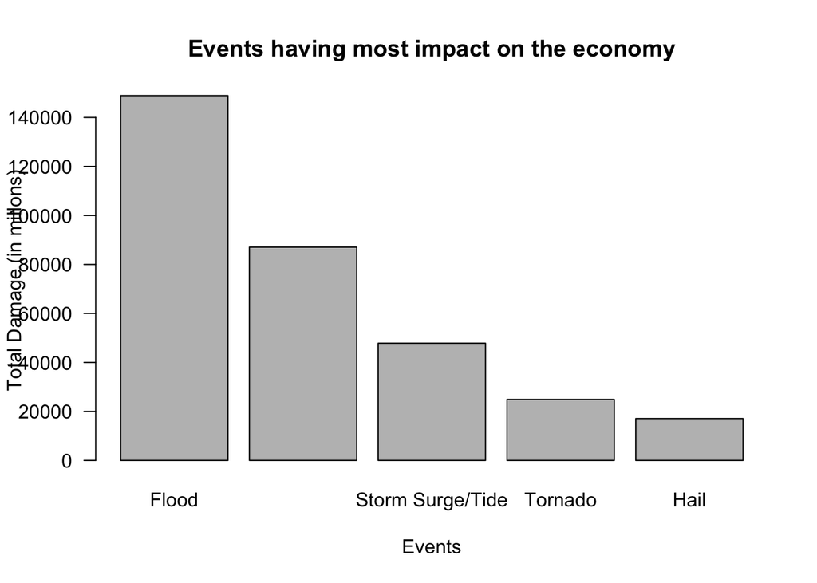

```r
barplot(totaldmg$TOTALDMG,names.arg=totaldmg$event_type,xlab="Events",ylab="Total Damage (in millons)",horiz=FALSE,main="Events having most impact on the economy", las="1")
```

```r
#lines(totaldmg$TOTALDMG,names.arg=totaldmg$event_type,lwd="1")
```

The following table show the top 5 events that most impact on the economy

```r
totaldmg[,c('event_type','TOTALDMG')]
```

```
## Source: local data frame [5 x 2]
##
##            event_type  TOTALDMG
##                (fctr)     (dbl)
## 1               Flood 148919.61
## 2 Hurricane (Typhoon)  87069.00
## 3    Storm Surge/Tide  47835.63
## 4             Tornado  24906.10
## 5                Hail  17092.04
```